# 05-Tarea

Teresa Ortiz

1. En este ejercicio utilizaremos la red [Child](http://www.bnlearn.com/bnrepository/) (D. J. Spiegelhalter, R. G. Coewll). El objetivo es que utilices el algoritmo de *hill climbing* para recuperar la estructura de la red a partir de una muestra.

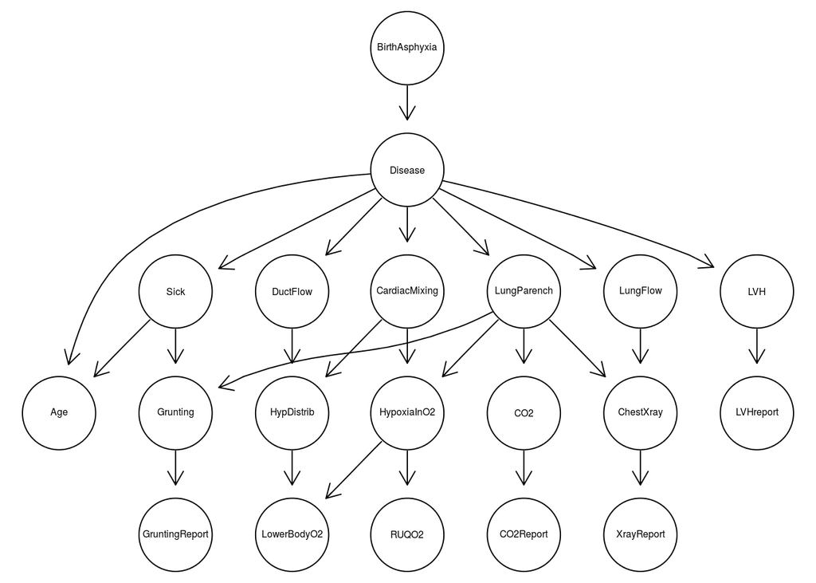

```r
library(bnlearn)
child_net <- read.net("child.net")
graphviz.plot(child_net)
```

- Los datos *muestra_ch.dat* fueron generandos simulando de la red *Child* y los utilizarás para recuperar la estructura utilizando como score el $AIC$ y el $BIC$, repite la estimación tomando muestras de tamaño $n = 500, 1000$.

En los próximos incisos utilizaremos la muestra de tamaño 500.

- Supón ahora que los expertos te informan que BirthAsphyxia debe ser nodo raíz (no puede haber arcos dirigidos hacia BirthAsphyxia) y GruntingReport, CO2Report, son nodos sin hijos (hojas). Incorpora esta información en tu red (utiliza el parámetro *blacklist* de la función *hc*) y aprende nuevamente las redes usando los criterios AIC y BIC
- Utiliza la función *arc.strength* con criterio AIC para calcular la fuerza de los arcos en la gráfica correspondiente al score AIC en el inciso anterior. La fuerza indica en cuanto reduce el score cada uno de los arcos. Incluye esta información en la gráfica de la red utilizando la función *strength.plot*.
2. Ahora repetiremos el *aprendizaje de estructura* 500 veces con el objetivo de explorar un número mayor de estructuras y reducir el impacto de máximos locales en el proceso de aprender estructura. Para esto se generan muestras *bootstrap* de los datos (muestras con reemplazo de la misma dimensión que los datos originales), para cada muestra se aprende una red. Las redes aprendidas se promedian con el fin de producir un modelo más robusto. Crearemos la **red promedio** utilizando los arcos presentes en al menos el 80% de las redes. Esta proporción mide la **fuerza** de cada arco.
- Utiliza la función *boot.strength* (algoritmo *hc*, argumentos *list(score = “aic”, blacklist = blist)*) para generar 500 redes. La función te regresará un data.frame con la *fuerza* de cada arco, imprime los 20 arcos con mayor fuerza.
- Utiliza la función *averaged.network* con un parámetro *threshold* de 0.8 para obtener la red promedio.